# Predicting Life Expectancy based on Socio-Economic and Health Factors

## 6.2 Hyperparameter Tuning (cp)

Hyperparameter tuning involves finding the optimal set of parameters that balance model complexity and predictive performance. In CART, it is the complexity parameter (cp), which governs how much the tree is pruned. Cross-validation searches over the defined cp grid and outputs the best cp value based on classification accuracy.

```r
# Define a tuning grid for cp values
tune_grid <- expand.grid(cp = seq(0.001, 0.05, by = 0.005))

# Set up cross-validation parameters
train_control <- trainControl(method = "cv", number = 10)

# Train the CART classification model using caret
cart_tuned <- train(LE_binary ~ Adult.Mortality + BMI + GDP + Status + infant.deaths + Alcohol + percentage.expenditure + Hepatitis.B + Measles + under.five.deaths + Polio + Total.expenditure + Diphtheria + HIV.AIDS + Population + thinness..1.19.years + thinness.5.9.years + Income.composition.of.resources + Schooling,
                    data = train_data,
                    method = "rpart",
                    tuneGrid = tune_grid,
                    trControl = train_control)

# Display the tuning results
print(cart_tuned)
```

```
CART

1155 samples
  19 predictor
   2 classes: 'Low', 'High'

No pre-processing
Resampling: Cross-Validated (10 fold)
Summary of sample sizes: 1040, 1040, 1040, 1039, 1038, 1040, ...
Resampling results across tuning parameters:

  cp     Accuracy   Kappa
  0.001  0.9038668  0.8077377
  0.006  0.9082146  0.8164058
  0.011  0.9091213  0.8182450
  0.016  0.9073821  0.8147828
  0.021  0.9021648  0.8043446
  0.026  0.8987090  0.7974348
  0.031  0.8995710  0.7991589
  0.036  0.8813627  0.7626587
  0.041  0.8796235  0.7591480
  0.046  0.8796235  0.7591480

Accuracy was used to select the optimal model using the largest value.
The final value used for the model was cp = 0.011.
```

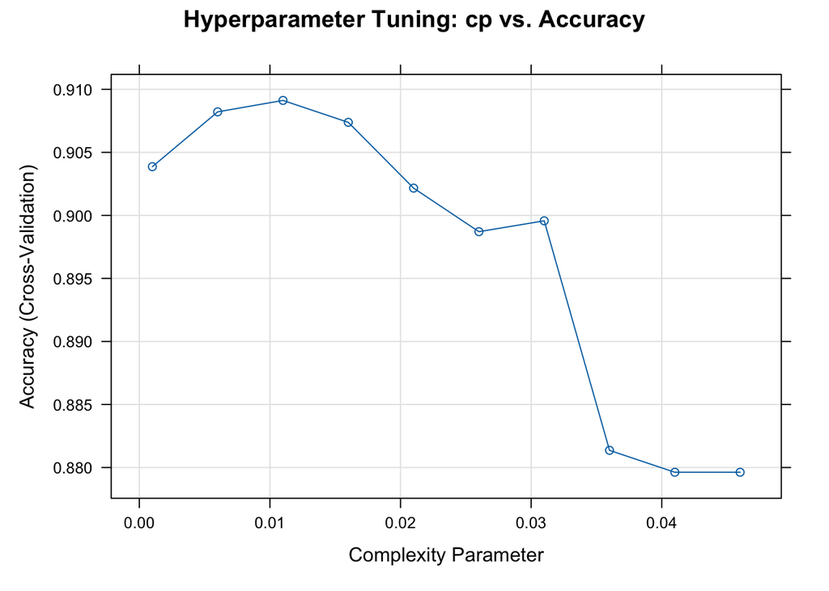

```r
plot(cart_tuned, main = "Hyperparameter Tuning: cp vs. Accuracy")
```

Overall, the plot shows that a relatively low cp which allows for more complex trees. This tuning results suggests the dataset contains enough variation and relevant splits for deeper trees without the risk of overfitting.

## 6.3 Final Model Training

Once the hyperparameter tuning process has identified the optimal cp for the CART model, the next step is to train the final classification tree using the training dataset. This process uses the best cp value from tuning, and the final CART regression tree is used to train the training data. The cp value represents the optimal tradeoff between underfitting and overfitting for the dataset. Using the optimal cp, the CART model is built on the training set. The response variable is the binary outcome LE_binary which categorizes life expectancy as “Low” or “High” based on the median value. All the predictors related to social, economic, and health metrics are included in the model. Finally, the structure of the trained model is generated. This plot provides an interpretable representation of the decision rules within the tree,showing how predictors are used to classify observations into “High” or “Low” life expectancy categories. The plot also includes other details such as node labels and decision criteria.

```r
library(rpart)
library(rpart.plot)
# Extract the best cp value from tuning results
best_cp <- cart_tuned$bestTune$cp
cat("Best cp selected:", best_cp, "\n")
```

```
Best cp selected: 0.011
```

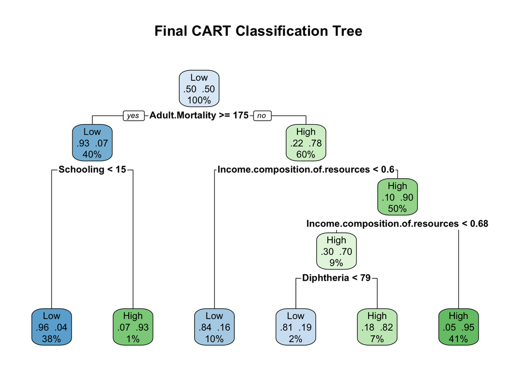

```r
# Train the final CART classification model using the optimal cp value
final_cart <- rpart(LE_binary ~ Adult.Mortality + BMI + GDP + Status + infant.deaths + Alcohol + percentage.expenditure + Hepatitis.B + Measles + under.five.deaths + Polio + Total.expenditure + Diphtheria + HIV.AIDS + Population + thinness..1.19.years + thinness.5.9.years + Income.composition.of.resources + Schooling,
                    data = train_data,
                    method = "class",
                    control = rpart.control(cp = best_cp))

# Visualize the final classification tree
rpart.plot(final_cart, extra = 104, fallen.leaves = TRUE,
           main = "Final CART Classification Tree")
```

## 6.4 Predictions on Test Data and Determining the Optimal Cut-Off

After developing and tuning the final CART classification model, the next step is to evaluate its performance on unseen data. In this section, predictions is generated on the test set by obtaining the predicted probabilities. The predicted probabilities is obtained first for the “high” class and an optimal cut-off probability is determined using ROC analysis. Then, the probabilities is converted into class predictions based on the optimal cut-off value. This process ensures that the final model evaluation is based on well calibrated decision rule, improving reliability of performance metrics.

```r
# Get predicted probabilities for the "High" class (second column)
cart_probs <- predict(final_cart, newdata = test_data, type = "prob")[,2]

# ROC analysis to determine optimal cutoff (Youden’s index)
roc_cart <- roc(response = test_data$LE_binary, predictor = cart_probs, levels = c("Low", "High"))
optimal_cutoff <- coords(roc_cart, x = "best", best.method = "youden", ret = "threshold")
optimal_cutoff_num <- unlist(optimal_cutoff)
cat("Optimal cutoff probability:", optimal_cutoff_num, "\n")
```

```
Optimal cutoff probability: 0.5059524
```

```r
# Convert probabilities into class labels using the optimal cutoff
cart_pred_class <- factor(ifelse(cart_probs > optimal_cutoff_num, "High", "Low"), levels = c("Low", "High"))
```

## 6.5 Performance Evaluation

Once the model is trained and optimal probability thresholds determined, its is essential to evaluate how well the CART classifier performs on unseen data. The model is assessed using several standard performance metrics. The classification performance is evaluated using a confusion matrix and performance metric such as overall accuracy, sensitivity, and specificity is calculated. A confusion matrix provides a detailed breakdown of the model’s predictions, with number of true positives, true negatives, false positives and false negatives. Key metrics such as overall accuracy - the proportion of correctly classified observations, sensitivity - the model’s ability to correctly identify “High” life expectancy, and specificity - the model’s ability to correctly identify “Low” life expectancy, are used. The ROC curve plots the trade-off between sensitivity and specificity at various thresholds. The AUC and ROC summarizes the model’s discrimination ability.

```r
conf_mat_cart <- confusionMatrix(cart_pred_class, test_data$LE_binary, positive = "High")
print(conf_mat_cart)
```

```
Confusion Matrix and Statistics

          Reference
Prediction Low High
      Low  231   37
      High  18  208

               Accuracy : 0.8887
                 95% CI : (0.8576, 0.915)
    No Information Rate : 0.504
    P-Value [Acc > NIR] : < 2e-16

                  Kappa : 0.7772

 Mcnemar's Test P-Value : 0.01522

            Sensitivity : 0.8490
            Specificity : 0.9277
         Pos Pred Value : 0.9204
         Neg Pred Value : 0.8619
             Prevalence : 0.4960
         Detection Rate : 0.4211
   Detection Prevalence : 0.4575
      Balanced Accuracy : 0.8883

       'Positive' Class : High
```

```r
auc_cart <- auc(roc_cart)
cat("AUC for CART Model:", auc_cart, "\n")
```

```
AUC for CART Model: 0.9154905
```

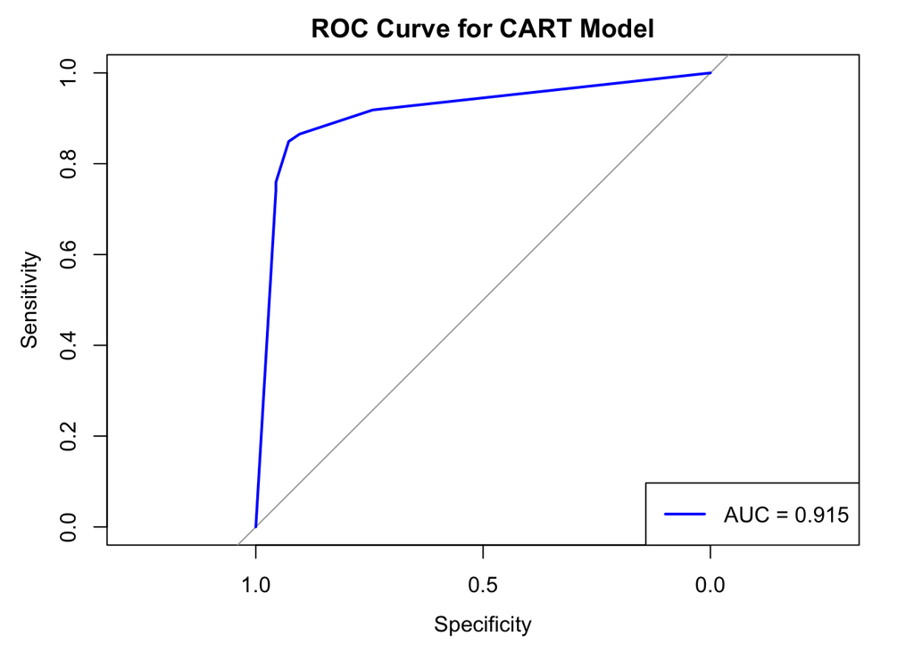

```r
# Generate ROC object using actual test outcomes and predicted probabilities.
roc_cart <- roc(response = test_data$LE_binary,
                predictor = cart_probs,
                levels = c("Low", "High"),
                direction = "<")  # 'direction' depends on how your probabilities are set up.

# Compute AUC from the ROC object
auc_cart <- auc(roc_cart)

# Plot the ROC curve
plot(roc_cart, col = "blue", lwd = 2, main = "ROC Curve for CART Model")

# Add a legend with the AUC value on the plot
legend("bottomright", legend = paste("AUC =", round(auc_cart, 3)),

           col = "blue", lwd = 2)
```

## 6.6 CART Regression Tree

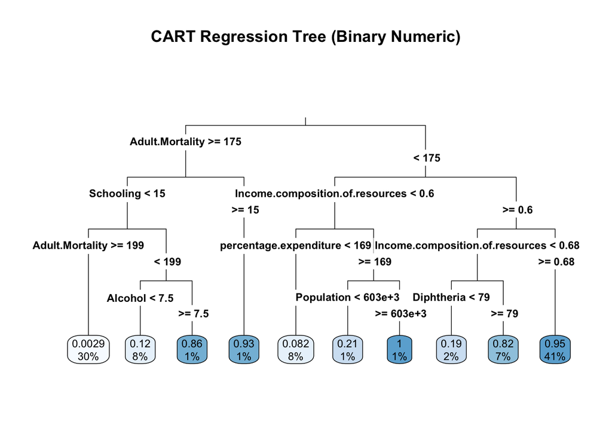

```r
# Build CART regression tree
# Exclude original Life.expectancy and LE_binary from predictors
reg_formula <- as.formula("LE_numeric ~ . - Life.expectancy - LE_binary")
cart_reg <- rpart(reg_formula, data = train_data, method = "anova", control = rpart.control(cp = 0.01))
rpart.plot(cart_reg, type = 3, fallen.leaves = TRUE, main = "CART Regression Tree (Binary Numeric)")
```

## 6.7 Regression model performance

In this section, the performance of two CART-based models are assessed and compared using regression metrics. CART Regression: This model is trained directly to predict the numeric variable (LE_numeric), with continuous values as outputs. Performance is evaluated using standard regression metrics such as Root Mean Squared Error (RMSE), Mean Absolute Error (MAE), and R-squared. CART Classification: This model outputs discrete class labels “High” and “Low”, which was then converted to numeric values 0 and 1 which allowed the use of regression performance metrics to assess the quality of the predictions.

```r
# Predict numeric outcomes for test data using the regression tree
reg_preds <- predict(cart_reg, newdata = test_data)

# Create a results data frame for comparison
results_reg <- test_data %>% select(LE_numeric) %>% mutate(Predicted = reg_preds)
head(results_reg)
```

```
   LE_numeric   Predicted
4           0 0.002881844
5           0 0.002881844
15          0 0.002881844
17          1 0.949260042
18          1 0.949260042
20          1 0.949260042
```

```r
# Compute regression performance metrics: RMSE, MAE, and R²
reg_perf <- postResample(pred = reg_preds, obs = test_data$LE_numeric)
print(reg_perf)
```

```
     RMSE  Rsquared       MAE
0.2859973 0.6800362 0.1343236
```

```r
# Convert classification predictions to numeric: "High"= 1, "Low"= 0
cart_pred_numeric <- ifelse(cart_pred_class == "High", 1, 0)

# Compute regression metrics comparing these converted predictions to the true numeric labels:
class_perf_reg <- postResample(pred = cart_pred_numeric, obs = test_data$LE_numeric)
print(class_perf_reg)
```

```
     RMSE  Rsquared       MAE
0.3336705 0.6076005 0.1113360
```

```r
performance_table <- tibble(
  Model = c("CART Classification (Converted to Numeric)", "CART Regression"),
  RMSE = c(class_perf_reg["RMSE"], reg_perf["RMSE"]),
  MAE = c(class_perf_reg["MAE"], reg_perf["MAE"]),
  R2 = c(class_perf_reg["Rsquared"], reg_perf["Rsquared"]),
  AUC = c(auc_cart, NA)  # AUC is computed only for classification; NA for regression
)
knitr::kable(performance_table, caption = "Performance Metrics Comparison")
```

Performance Metrics Comparison

| Model | RMSE | MAE | R2 | AUC |
| --- | --- | --- | --- | --- |
| CART Classification (Converted to Numeric) | 0.3336705 | 0.1113360 | 0.6076005 | 0.9154905 |
| CART Regression | 0.2859973 | 0.1343236 | 0.6800362 | NA |

Comparative analysis:

1. RMSE & MAE:

Regression produced predictions that may lie between 0 and 1 leading to fractional output which can sometimes increase the absolute error.

2. Variance (R-squared):